# 一言不合就学R

[商务大数据智能分析](http://xiangyuchang.github.io/course17/index.html) 之 **R4**

Lecturer : 申 旌 周  
jingzhou_shen@stu.xjtu.edu.cn

Instructor : 常 象 宇  
xiangyuchang@xjtu.edu.cn

2017年4月9日

### 概览

- Linear Model for Regression
- Linear Model for Classification

### Linear Model for Regression

- Linear Regression
- Stepwise Regression
- Ridge
- LASSO

### Linear Regression

- Data
- Simple Linear Regression
- Multiple Linear Regression

### Data

```r
library(MASS)
```

```r
str(birthwt)
```

```
'data.frame':   189 obs. of  10 variables:
 $ low  : int  0 0 0 0 0 0 0 0 0 0 ...
 $ age  : int  19 33 20 21 18 21 22 17 29 26 ...
 $ lwt  : int  182 155 105 108 107 124 118 103 123 113 ...
 $ race : int  2 3 1 1 1 3 1 3 1 1 ...
 $ smoke: int  0 0 1 1 1 0 0 0 1 1 ...
 $ ptl  : int  0 0 0 0 0 0 0 0 0 0 ...
 $ ht   : int  0 0 0 0 0 0 0 0 0 0 ...
 $ ui   : int  1 0 0 1 1 0 0 0 0 0 ...
 $ ftv  : int  0 3 1 2 0 0 1 1 1 0 ...
 $ bwt  : int  2523 2551 2557 2594 2600 2622 2637 2637 2663 2665 ...
```

### Data

```r
head(birthwt)
```

```
   low age lwt race smoke ptl ht ui ftv  bwt
85   0  19 182    2     0   0  0  1   0 2523
86   0  33 155    3     0   0  0  0   3 2551
87   0  20 105    1     1   0  0  0   1 2557
88   0  21 108    1     1   0  0  1   2 2594
89   0  18 107    1     1   0  0  1   0 2600
91   0  21 124    3     0   0  0  0   0 2622
```

```r
colnames(birthwt) <-
  c("birthwt.below.2500",
    "mother.age", "mother.weight",
    "race", "mother.smokes", "previous.prem.labor",
    "hypertension", "uterine.irr", "physician.visits",
    "birthwt.grams")
```

### Data

```r
birthwt$race <- as.factor(birthwt$race)
```

```r
(attr(birthwt$race, "levels") <- c("White", "Black", "Other"))
```

```
[1] "White" "Black" "Other"
```

```r
birthwt$mother.smokes <- as.factor(birthwt$mother.smokes)
```

```r
(attr(birthwt$mother.smokes, "levels") <- c("Nonsmoker", "Smoker"))
```

```
[1] "Nonsmoker" "Smoker"
```

### Simple Linear Regression

```r
lm(birthwt.grams ~ mother.age, data = birthwt)
```

```
Call:
lm(formula = birthwt.grams ~ mother.age, data = birthwt)

Coefficients:
(Intercept)   mother.age
    2655.74        12.43
```

### Simple Linear Regression

```r
library(ggplot2)
```

```r
# birthwt.grams ~ mother.age
p <- ggplot(
  birthwt,
  aes(x = mother.age, y = birthwt.grams))
```

```r
plot.simple <- p +
  geom_point(aes(colour = race),
             size = 4) +
  stat_smooth(method = "lm") +
  theme(text = element_text(size = 22))
```

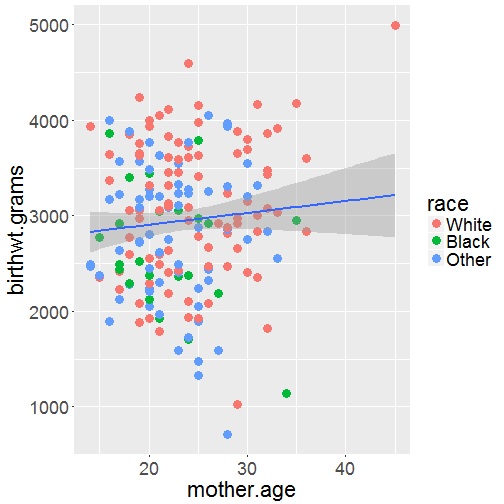

```r
plot.simple
```

### Simple Linear Regression

```r
slr <- lm(birthwt.grams ~ mother.age, data = birthwt)
```

```r
attributes(slr)
```

```
$names
 [1] "coefficients"  "residuals"     "effects"       "rank"
 [5] "fitted.values" "assign"        "qr"            "df.residual"
 [9] "xlevels"       "call"          "terms"         "model"

$class
[1] "lm"
```

### Simple Linear Regression

```r
summary(slr)
```

```
Call:
lm(formula = birthwt.grams ~ mother.age, data = birthwt)

Residuals:
     Min       1Q   Median       3Q      Max
-2294.78  -517.63    10.51   530.80  1774.92

Coefficients:
            Estimate Std. Error t value Pr(>|t|)
(Intercept)  2655.74     238.86   11.12   <2e-16 ***
mother.age     12.43      10.02    1.24    0.216
---
Signif. codes:  0 '***' 0.001 '**' 0.01 '*' 0.05 '.' 0.1 ' ' 1

Residual standard error: 728.2 on 187 degrees of freedom
Multiple R-squared:  0.008157,  Adjusted R-squared:  0.002853
F-statistic: 1.538 on 1 and 187 DF,  p-value: 0.2165
```

### Multiple Linear Regression

```r
mlr <- lm(birthwt.grams ~ mother.age + race, data = birthwt)
```

```r
mlr
```

```
Call:
lm(formula = birthwt.grams ~ mother.age + race, data = birthwt)

Coefficients:
(Intercept)   mother.age    raceBlack    raceOther
   2949.979        6.288     -365.715     -285.466
```

**Birthweight = Intercept(based on race) + \( \large\beta \) * mother's age**

\[ \begin{equation}\large y = \text{Intercept}_{race} + \beta \times \text{age} \end{equation} \]

### Multiple Linear Regression

```r
coef(mlr)
```

```
(Intercept)  mother.age   raceBlack   raceOther
2949.979032    6.287741 -365.715000 -285.465780
```

```r
confint(mlr)
```

```
                 2.5 %     97.5 %
(Intercept) 2446.20259 3453.75547
mother.age   -13.58435   26.15984
raceBlack   -682.62810  -48.80190
raceOther   -513.39407  -57.53749
```

```r
intercepts <- c(
  coef(mlr)["(Intercept)"],
  coef(mlr)["(Intercept)"] + coef(mlr)["raceBlack"],
  coef(mlr)["(Intercept)"] + coef(mlr)["raceOther"])

lines.df <- data.frame(
  intercepts = intercepts, slopes = rep(coef(mlr)["mother.age"], 3),
  race = levels(birthwt$race))
```

### Multiple Linear Regression

```r
plot.mlr <-
  ggplot(x = mother.age,
        y = birthwt.grams,
        color = race,
        data = birthwt) +
  geom_abline(
    aes(
      intercept = intercepts,
      slope = slopes,
      color = race),
    data = lines.df) +
  theme(text = element_text(size = 22))
```

[figure not shown]

```r
plot.mlr
```

### Multiple Linear Regression

```r
mlr.inter <- lm(birthwt.grams ~ mother.age * race, data = birthwt)
```

```r
mlr.inter
```

```
Call:
lm(formula = birthwt.grams ~ mother.age * race, data = birthwt)

Coefficients:
         (Intercept)            mother.age             raceBlack
             2583.54                 21.37               1022.79
           raceOther  mother.age:raceBlack  mother.age:raceOther
              326.05                -62.54                -26.03
```

**Birthweight = Intercept(based on race) + \( \large\beta \)(based on race) * mother's age**

\[ \begin{equation}\large y = \text{Intercept}_{race} + \beta_{race}\times \text{age} \end{equation} \]

### Multiple Linear Regression

```r
plot.mlr.inter <-
  qplot(x = mother.age,
        y = birthwt.grams,
        color = race,
        data = birthwt) +
  stat_smooth(
    method = "lm",
    se = FALSE,
    fullrange = TRUE) +
  theme(text = element_text(size = 22))
```

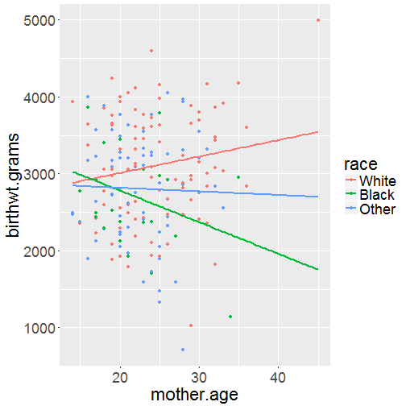

```r
plot.mlr.inter
```

### Multiple Linear Regression

- `birthwt.grams ~ mother.age + race`

[figure not shown]

```r
plot.mlr
```

\[ \begin{equation}\large y = \text{Intercept}_{race} + \beta \times \text{age} \end{equation} \]

- `birthwt.grams ~ mother.age * race`

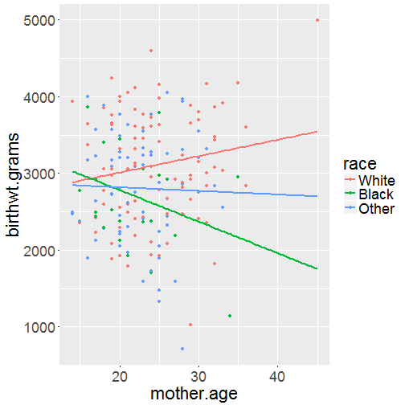

```r
plot.mlr.inter
```

\[ \begin{equation}\large y = \text{Intercept}_{race} + \beta_{race}\times \text{age} \end{equation} \]

### Multiple Linear Regression

```r
summary(mlr)
```

```
Call:
lm(formula = birthwt.grams ~ mother.age + race, data = birthwt)

Residuals:
     Min       1Q   Median       3Q      Max
-2131.57  -488.02    -1.16   521.87  1757.07

Coefficients:
            Estimate Std. Error t value Pr(>|t|)
(Intercept) 2949.979    255.352  11.553   <2e-16 ***
mother.age     6.288     10.073   0.624   0.5332
raceBlack   -365.715    160.636  -2.277   0.0240 *
raceOther   -285.466    115.531  -2.471   0.0144 *
---
Signif. codes:  0 '***' 0.001 '**' 0.01 '*' 0.05 '.' 0.1 ' ' 1

Residual standard error: 715.7 on 185 degrees of freedom
Multiple R-squared:  0.05217,   Adjusted R-squared:  0.0368
F-statistic: 3.394 on 3 and 185 DF,  p-value: 0.01909
```

### Multiple Linear Regression

```r
summary(mlr.inter)
```

```
Call:
lm(formula = birthwt.grams ~ mother.age * race, data = birthwt)

Residuals:
     Min       1Q   Median       3Q      Max
-2182.35  -474.23    13.48   523.86  1496.51

Coefficients:
                     Estimate Std. Error t value Pr(>|t|)
(Intercept)           2583.54     321.52   8.035 1.11e-13 ***
mother.age              21.37      12.89   1.658   0.0991 .
raceBlack             1022.79     694.21   1.473   0.1424
raceOther              326.05     545.30   0.598   0.5506
mother.age:raceBlack   -62.54      30.67  -2.039   0.0429 *
mother.age:raceOther   -26.03      23.20  -1.122   0.2633
---
Signif. codes:  0 '***' 0.001 '**' 0.01 '*' 0.05 '.' 0.1 ' ' 1

Residual standard error: 710.7 on 183 degrees of freedom
Multiple R-squared:  0.07541,   Adjusted R-squared:  0.05015
F-statistic: 2.985 on 5 and 183 DF,  p-value: 0.01291
```

### Stepwise Regression

```r
lm.full <- lm(birthwt.grams ~ ., data = birthwt)
```

```r
bwd <- step(lm.full, direction = "backward", trace = 0)
```

```r
lm.null <- lm(birthwt.grams ~ 1, data = birthwt)
```

```r
fwd <- step(lm.null, direction = "forward", scope = ( ~ birthwt.below.2500 + mother.age + mother.weight + race + mother.smokes + previous.prem.labor + hypertension + uterine.irr + physician.visits), trace = 0)
```

### Stepwise Regression

```r
summary(bwd)
```

```
Call:
lm(formula = birthwt.grams ~ birthwt.below.2500 + race + mother.smokes +
    uterine.irr, data = birthwt)

Residuals:
     Min       1Q   Median       3Q      Max
-1039.37  -338.51    30.49   298.19  1489.19

Coefficients:
                    Estimate Std. Error t value Pr(>|t|)
(Intercept)          3500.81      58.71  59.624  < 2e-16 ***
birthwt.below.2500  -1131.17      71.33 -15.857  < 2e-16 ***
raceBlack            -206.36      97.38  -2.119 0.035434 *
raceOther            -189.89      74.74  -2.541 0.011898 *
mother.smokesSmoker  -157.30      70.29  -2.238 0.026442 *
uterine.irr          -309.28      90.04  -3.435 0.000734 ***
---
Signif. codes:  0 '***' 0.001 '**' 0.01 '*' 0.05 '.' 0.1 ' ' 1

Residual standard error: 432 on 183 degrees of freedom
Multiple R-squared:  0.6584,    Adjusted R-squared:  0.6491
F-statistic: 70.55 on 5 and 183 DF,  p-value: < 2.2e-16
```

### Stepwise Regression

```r
summary(fwd)
```

```
Call:
lm(formula = birthwt.grams ~ birthwt.below.2500 + uterine.irr +
    race + mother.smokes, data = birthwt)

Residuals:
     Min       1Q   Median       3Q      Max
-1039.37  -338.51    30.49   298.19  1489.19

Coefficients:
                    Estimate Std. Error t value Pr(>|t|)
(Intercept)          3500.81      58.71  59.624  < 2e-16 ***
birthwt.below.2500  -1131.17      71.33 -15.857  < 2e-16 ***
uterine.irr          -309.28      90.04  -3.435 0.000734 ***
raceBlack            -206.36      97.38  -2.119 0.035434 *
raceOther            -189.89      74.74  -2.541 0.011898 *
mother.smokesSmoker  -157.30      70.29  -2.238 0.026442 *
---
Signif. codes:  0 '***' 0.001 '**' 0.01 '*' 0.05 '.' 0.1 ' ' 1

Residual standard error: 432 on 183 degrees of freedom
Multiple R-squared:  0.6584,    Adjusted R-squared:  0.6491
F-statistic: 70.55 on 5 and 183 DF,  p-value: < 2.2e-16
```

### Stepwise Regression

```r
wise <- step(lm.full, trace = 0);  summary(wise)
```

```
Call:
lm(formula = birthwt.grams ~ birthwt.below.2500 + race + mother.smokes +
    uterine.irr, data = birthwt)

Residuals:
     Min       1Q   Median       3Q      Max
-1039.37  -338.51    30.49   298.19  1489.19

Coefficients:
                    Estimate Std. Error t value Pr(>|t|)
(Intercept)          3500.81      58.71  59.624  < 2e-16 ***
birthwt.below.2500  -1131.17      71.33 -15.857  < 2e-16 ***
raceBlack            -206.36      97.38  -2.119 0.035434 *
raceOther            -189.89      74.74  -2.541 0.011898 *
mother.smokesSmoker  -157.30      70.29  -2.238 0.026442 *
uterine.irr          -309.28      90.04  -3.435 0.000734 ***
---
Signif. codes:  0 '***' 0.001 '**' 0.01 '*' 0.05 '.' 0.1 ' ' 1

Residual standard error: 432 on 183 degrees of freedom
Multiple R-squared:  0.6584,    Adjusted R-squared:  0.6491
F-statistic: 70.55 on 5 and 183 DF,  p-value: < 2.2e-16
```

### 回归诊断

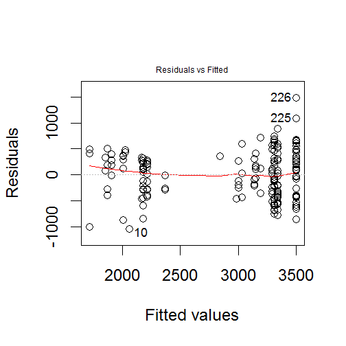

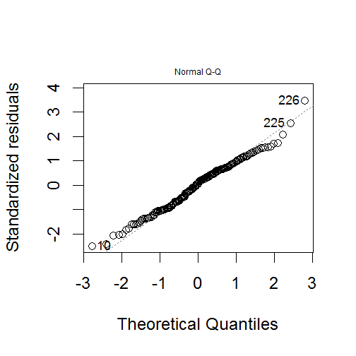

```r
par(cex = 2)
plot(wise, which = c(1, 2), sub = "")
```

### 回归诊断

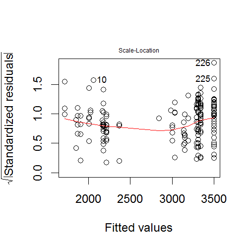

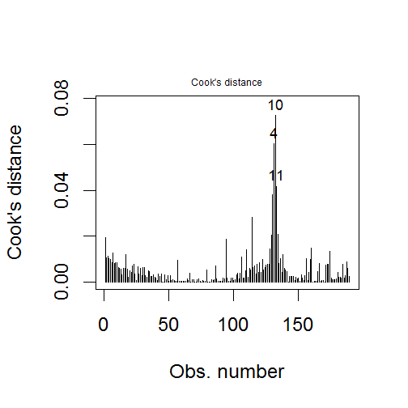

```r
par(cex = 2)
plot(wise, which = c(3, 4), sub = "")
```

### 回归诊断

- 残差正态性检验

```r
shapiro.test(wise$residuals)
```

```
    Shapiro-Wilk normality test

data:  wise$residuals
W = 0.98877, p-value = 0.142
```

- 残差自相关检验

```r
library(lmtest)
dwtest(wise)
```

```
    Durbin-Watson test

data:  wise
DW = 0.417, p-value < 2.2e-16
alternative hypothesis: true autocorrelation is greater than 0
```

- 离群点检测

```r
library(car)
outlierTest(wise)
```

```
No Studentized residuals with Bonferonni p < 0.05
Largest |rstudent|:
    rstudent unadjusted p-value Bonferonni p
226 3.590985         0.00042366     0.080071
```

### 预测

```r
(pred <- predict(wise, newdata = birthwt[c(3, 6, 7), ]))
```

```
      87       91       92
3343.513 3310.928 3500.814
```

```r
(real <- birthwt[c(3, 6, 7), "birthwt.grams"])
```

```
[1] 2557 2622 2637
```

```r
(mean(pred - real))
```

```
[1] 779.7516
```

```r
predict(wise, newdata = birthwt[c(3, 6, 7), ], interval = "prediction")
```

```
        fit      lwr      upr
87 3343.513 2482.964 4204.061
91 3310.928 2450.411 4171.445
92 3500.814 2640.684 4360.945
```

### 交乘项

- \[ \begin{equation}\large y_{i} = \beta_{0} + \beta_{1}u_{i} + \beta_{2}v_{i} + \beta_{3}u_{i}v_{i} + \varepsilon_{i} \end{equation} \]

```r
y ~ u * v
y ~ (u + v)^2
y ~ u + v + u:v
```

- \[ \begin{equation}\large y_{i} = \beta_{0} + \beta_{1}u_{i} + \beta_{2}v_{i} + \beta_{3}w_{i} + \beta_{4}u_{i}v_{i} + \beta_{5}u_{i}w_{i} + \varepsilon_{i} \end{equation} \]

```r
y ~ u + v + w + u:v + u:w
y ~ u + v + w + u(v + w)
```

```r
y ~ u * (v + w)
```

```r
y ~ u * v * w
```

### 多项式

- 多项式 \[ \begin{equation}\large y_{i} = \beta_{0} + \beta_{1}x_{i} + \beta_{2}x_{i}^{2} + \beta_{3}x_{i}^{3} + \varepsilon_{i} \end{equation} \]

```r
y ~ poly(x, 3, raw = TRUE)
y ~ x + I(x^2) + I(x^3)
```

- 截距项为**零** \[ \begin{equation}\large y_{i} = \beta x_{i} + \varepsilon_{i} \end{equation} \]

```r
y ~ x + 0
```

### Data - Ridge and LASSO

```r
library(lars)
data("diabetes") # 糖尿病患者的血液化验指标数据集
```

```r
#  y: 因变量； x: 标准化的自变量矩阵；
#  x2: 自变量矩阵, 由x及一些交互作用组成
names(diabetes)
```

```
[1] "x"  "y"  "x2"
```

```r
list(length(diabetes$y), dim(diabetes$x), dim(diabetes$x2))
```

```
[[1]]
[1] 442

[[2]]
[1] 442  10

[[3]]
[1] 442  64
```

```r
y <- diabetes$y
x <- diabetes$x
x2 <- diabetes$x2
```

### Ridge

```r
kappa(x2)
```

```
[1] 11427.09
```

```r
library(car)
y.x2 <- as.data.frame(cbind(y, x2))
v <- vif(lm(y ~ ., y.x2))
sort(v, decreasing = T)[1:5]
```

```
        tc        ldl        hdl        ltg   `tc:ltg`
1295001.21 1000312.11  180836.83  139965.06   61177.87
```

### Ridge

```r
library(MASS)
a <- lm.ridge(y ~ ., lambda = seq(0, 150, length = 151),
              data = y.x2, model = TRUE)
names(a)
```

```
[1] "coef"   "scales" "Inter"  "lambda" "ym"     "xm"     "GCV"    "kHKB"
[9] "kLW"
```

```r
a$lambda[which.min(a$GCV)]
```

```
[1] 81
```

```r
a$coef[which.min(a$GCV)]
```

```
[1] 17.12666
```

### Ridge

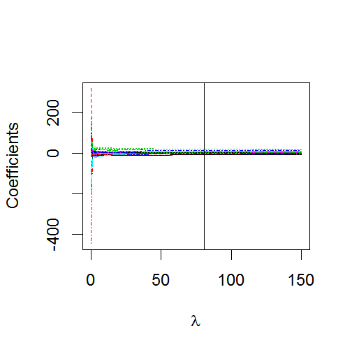

```r
par(cex = 2)
matplot(a$lambda, t(a$coef), xlab = expression(lambda), ylab = "Coefficients", type = "l", lty = 1:20)
abline(v = a$lambda[which.min(a$GCV)])
```

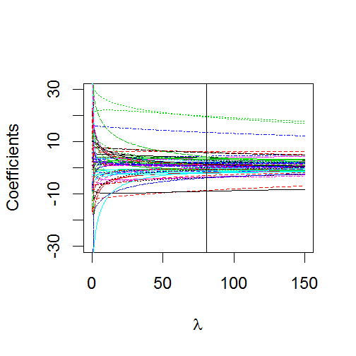

```r
par(cex = 2)
matplot(a$lambda, t(a$coef), xlab = expression(lambda), ylab = "Coefficients", type = "l", lty = 1:20, ylim = c(-30, 30))
abline(v = a$lambda[which.min(a$GCV)])
```

### Ridge

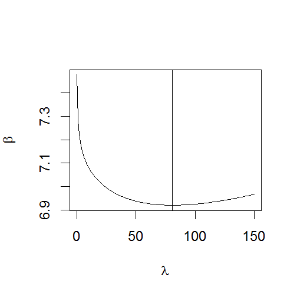

```r
par(cex = 2)
plot(a$lambda, a$GCV, xlab = expression(lambda), ylab = expression(beta), type = "l")
abline(v = a$lambda[which.min(a$GCV)])
```

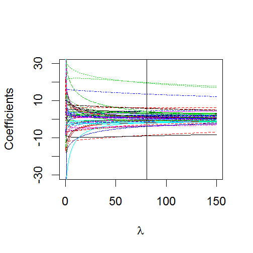

```r
par(cex = 2)
matplot(a$lambda, t(a$coef), xlab = expression(lambda), ylab = "Coefficients", type = "l", lty = 1:20, ylim = c(-30, 30))
abline(v = a$lambda[which.min(a$GCV)])
```

### LASSO

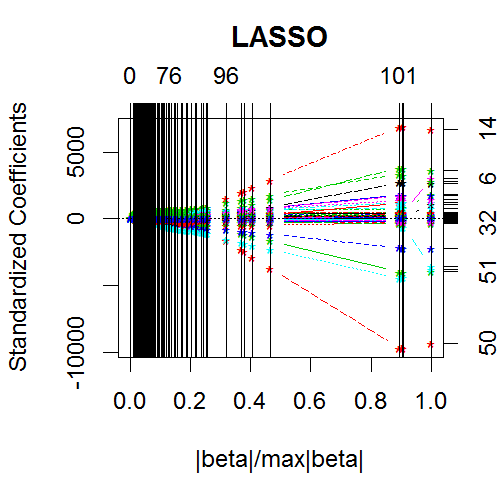

```r
laa <- lars(x2, y)
par(cex = 2)
plot(laa)
```

```r
dim(summary(laa))
```

```
[1] 105   3
```

```r
dim(summary(laa))
```

```
[1] 105   3
```

```r
min(laa$Cp)
```

```
[1] 18.19822
```

```r
# Cp在第15步时取得最小值
summary(laa)[13:20, ]
```

```
LARS/LASSO
Call: lars(x = x2, y = y)
   Df     Rss     Cp
12 13 1249726 25.058
13 14 1234993 21.858
14 15 1225552 20.526
15 16 1213289 18.198
16 17 1212253 19.833
17 18 1210149 21.090
18 19 1206003 21.627
19 20 1204605 23.134
```

### LASSO

```r
par(cex = 2)
cva <- cv.lars(x2, y, K = 10)
```

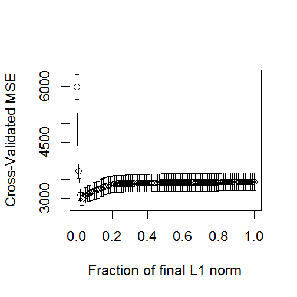

```r
(best <- cva$index[which.min(cva$cv)])
```

```
[1] 0.03030303
```

### LASSO

```r
coef <- coef.lars(laa, mode = "fraction", s = best)
coef[coef!=0]
```

```
        sex         bmi         map         hdl         ltg         glu
 -92.966618  502.356055  241.631884 -174.935230  465.398774   10.828814
      bmi^2       glu^2     age:sex     age:map     age:ltg     age:glu
  33.918974   62.355697   97.307919   28.427380    4.497064   13.779861
    bmi:map
  79.712186
```

```r
coef1 <- coef.lars(laa, mode = "step", s = 15)
coef1[coef1!=0]
```

```
        sex         bmi         map         hdl         ltg         glu
-112.312541  501.616811  251.792232 -187.827872  467.778725   18.130314
      age^2       bmi^2       glu^2     age:sex     age:map     age:ltg
   7.608734   38.748381   69.809696  107.727556   30.045318    8.613394
    age:glu     bmi:map
  11.600284   85.688057
```

```r
c(length(coef[coef!=0]), length(coef1[coef1!=0]))
```

```
[1] 13 14
```

### Linear Model for Classification

- Data
- Linear Discriminant Analysis
- Logistic Regression

### Data

- [脊柱数据](http://archive.ics.uci.edu/ml/datasets/Vertebral+Column)

```r
vertebral.two <- read.table("./data/vertebral_column_data/column_2C.dat")
head(vertebral.two, 2)
```

```
     V1    V2    V3    V4     V5    V6 V7
1 63.03 22.55 39.61 40.48  98.67 -0.25 AB
2 39.06 10.06 25.02 29.00 114.41  4.56 AB
```

```r
c(mean(vertebral.two[, "V6"]), vertebral.two[116, "V6"])
```

```
[1]  26.29674 418.54000
```

```r
runin <- lm(V6 ~ ., vertebral.two[-116, ])
vertebral.two[116, 6] <- predict(runin, vertebral.two[116, -6])
```

```r
c(mean(vertebral.two[, "V6"]), vertebral.two[116, "V6"])
```

```
[1] 25.11047 50.79539
```

### Linear Discriminant Analysis

```r
library(MASS)
```

```r
model.lda <- lda(V7 ~ ., data = vertebral.two)
```

```r
result.pred <- predict(model.lda, vertebral.two)$class
```

```r
(confusion <- table(vertebral.two[, 7], result.pred))
```

```
    result.pred
      AB  NO
  AB 188  22
  NO  23  77
```

```r
(error.rate <- (sum(confusion)-sum(diag(confusion)))/sum(confusion))
```

```
[1] 0.1451613
```

### Logistic Regression

```r
model.logistic <- glm(V7 ~ ., data = vertebral.two, family = "binomial")
```

```r
model.logistic <- step(model.logistic, trace = 0)
```

```r
is.NO <- (predict(model.logistic, vertebral.two, type = "response") > 0.5)
```

```r
result.pred <- rep("NO", nrow(vertebral.two))
result.pred[!is.NO] <- "AB"
```

```r
(confusion <- table(vertebral.two[, 7], result.pred))
```

```
    result.pred
      AB  NO
  AB 186  24
  NO  22  78
```

```r
(error.rate <- (sum(confusion)-sum(diag(confusion)))/sum(confusion))
```

```
[1] 0.1483871
```

```r
summary(model.logistic)
```

```
Call:
glm(formula = V7 ~ V1 + V2 + V3 + V5 + V6, family = "binomial",
    data = vertebral.two)

Deviance Residuals:
     Min        1Q    Median        3Q       Max
-2.19329  -0.37733  -0.02971   0.40452   2.69386

Coefficients:
             Estimate Std. Error z value Pr(>|z|)
(Intercept) -14.74316    3.20375  -4.602 4.19e-06 ***
V1            0.08323    0.02416   3.445 0.000571 ***
V2           -0.16219    0.03586  -4.523 6.10e-06 ***
V3            0.02729    0.01953   1.397 0.162357
V5            0.10493    0.02271   4.619 3.85e-06 ***
V6           -0.17023    0.02336  -7.288 3.15e-13 ***
---
Signif. codes:  0 '***' 0.001 '**' 0.01 '*' 0.05 '.' 0.1 ' ' 1

(Dispersion parameter for binomial family taken to be 1)

    Null deviance: 389.86  on 309  degrees of freedom
Residual deviance: 178.98  on 304  degrees of freedom
AIC: 190.98

Number of Fisher Scoring iterations: 7
```

### Logistic Regression

```r
library(knitr)
kable(summary(model.logistic)$coef, digits = 4)
```

|  | Estimate | Std. Error | z value | Pr(>\|z\|) |
| --- | --- | --- | --- | --- |
| (Intercept) | -14.7432 | 3.2037 | -4.6018 | 0.0000 |
| V1 | 0.0832 | 0.0242 | 3.4452 | 0.0006 |
| V2 | -0.1622 | 0.0359 | -4.5231 | 0.0000 |
| V3 | 0.0273 | 0.0195 | 1.3972 | 0.1624 |
| V5 | 0.1049 | 0.0227 | 4.6193 | 0.0000 |
| V6 | -0.1702 | 0.0234 | -7.2879 | 0.0000 |

**Thank you**

[figure not shown]